# Dissolved Oxygen Recovery Project

AZMP cruise data was searched manually to find cruises where there were both Winkler and probe measurements. Within Gordana’s files there were three cruises which qualified, HUD2011004, HUD2011043 and HUD2012042

These files were read in as csv’s using the BCD flagged files to provide the most accurate and up to date QC. Once the files were copied from the shared drive to the local drive they were read in as seen below (caution this section will not run unless file paths are exact)

```r
#read in BCD files
H11004_bcd <- read.csv('HUD2011004/HUD2011004_BCD_flagged.csv')
H11043_bcd <- read.csv('HUD2011043/HUD2011043_BCD_flagged.csv')
H12042_bcd <- read.csv('HUD2012042/HUD2012042_BCD_flagged.csv')
```

Once files were read into R, Winkler and probe data was found and pulled.

```r
#find rows with winkler data
H11004_wink <- grep(H11004_bcd$DATA_TYPE_METHOD, pattern = 'O2_Winkler_Auto')
H11043_wink <- grep(H11043_bcd$DATA_TYPE_METHOD, pattern = 'O2_Winkler_Auto')
H12042_wink <- grep(H12042_bcd$DATA_TYPE_METHOD, pattern = 'O2_Winkler_Auto')
#find rows with probe data
H11004_elec <- grep(H11004_bcd$DATA_TYPE_METHOD, pattern = 'O2_Electrode_mll')
H11043_elec <- grep(H11043_bcd$DATA_TYPE_METHOD, pattern = 'O2_Electrode_mll')
H12042_elec <- grep(H12042_bcd$DATA_TYPE_METHOD, pattern = 'O2_Electrode_mll')
#pull winkler data
H11004_wink_data <- H11004_bcd$DIS_DETAIL_DATA_VALUE[H11004_wink]
H11004_wink_dpth <- H11004_bcd$DIS_HEADER_START_DEPTH[H11004_wink]
H11043_wink_data <- H11043_bcd$DIS_DETAIL_DATA_VALUE[H11043_wink]
H11043_wink_dpth <- H11043_bcd$DIS_HEADER_START_DEPTH[H11043_wink]
H12042_wink_data <- H12042_bcd$DIS_DETAIL_DATA_VALUE[H12042_wink]
H12042_wink_dpth <- H12042_bcd$DIS_HEADER_START_DEPTH[H12042_wink]
#pull probe data
H11004_elec_data <- H11004_bcd$DIS_DETAIL_DATA_VALUE[H11004_elec]
H11004_elec_dpth <- H11004_bcd$DIS_HEADER_START_DEPTH[H11004_elec]
H11043_elec_data <- H11043_bcd$DIS_DETAIL_DATA_VALUE[H11043_elec]
H11043_elec_dpth <- H11043_bcd$DIS_HEADER_START_DEPTH[H11043_elec]
H12042_elec_data <- H12042_bcd$DIS_DETAIL_DATA_VALUE[H12042_elec]
H12042_elec_dpth <- H12042_bcd$DIS_HEADER_START_DEPTH[H12042_elec]
```

Once probe and Winkler data has been isolated, an initial plot gives a general idea of the data set for each cruise.

```r
plot(H11004_wink_data, H11004_wink_dpth, ylim = c(5000, 0), xlim = c(3, 9), col = 'blue', ylab = 'Depth (m)', xlab = 'O2 concentration (ml/l)',main = 'Oxygen data from HUD2011004', sub = 'Winkler vs Probe(Orion 842)')
par(new = TRUE)
```

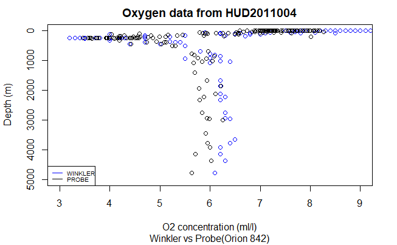

```r
plot(H11004_elec_data, H11004_elec_dpth, ylim = c(5000, 0), xlim = c(3, 9), axes = FALSE, col = 'black', xlab = '', ylab = '')
legend('bottomleft', legend = c('WINKLER', 'PROBE'), col = c('blue', 'black'), lty = 1, cex = 0.6)
```

```r
plot(H11043_wink_data, H11043_wink_dpth, ylim = c(5000, 0), xlim = c(2, 9), col = 'blue', ylab = 'Depth (m)', xlab = 'O2 concentration (ml/l)',main = 'Oxygen data from HUD2011043', sub = 'Winkler vs Probe(Orion 842)')
par(new = TRUE)
```

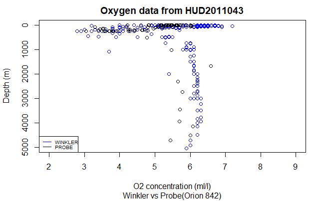

```r
plot(H11043_elec_data, H11043_elec_dpth, ylim = c(5000, 0), xlim = c(2, 9), axes = FALSE, col = 'black', xlab = '', ylab = '')
legend('bottomleft', legend = c('WINKLER', 'PROBE'), col = c('blue', 'black'), lty = 1, cex = 0.6)
```

```r
plot(H12042_wink_data, H12042_wink_dpth, ylim = c(5000, 0), xlim = c(1, 9), col = 'blue', ylab = 'Depth (m)', xlab = 'O2 concentration (ml/l)',main = 'Oxygen data from HUD2012042', sub = 'Winkler vs Probe(Orion 842)')
par(new = TRUE)
```

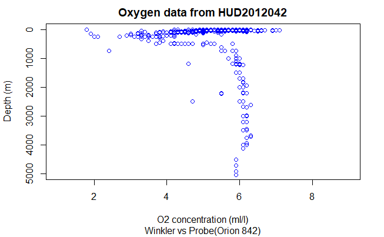

```r
plot(H12042_elec_data, H12042_elec_dpth, ylim = c(5000, 0), xlim = c(1, 9), axes = FALSE, col = 'black', xlab = '', ylab = '')
legend('bottomleft', legend = c('WINKLER', 'PROBE'), col = c('blue', 'black'), lty = 1, cex = 0.6)
```

The next step in analysis was to match the sample ID’s for each measurement method so that DO could be directly compared. There was a minor bug with the length of the vectors but this was easily solved.

```r
#isolate individual bottles
#hud2011004
#pull sample ids
H11004_wink_id <- H11004_bcd$DIS_DETAIL_COLLECTOR_SAMP_ID[H11004_wink] #length = 137
H11004_elec_id <- H11004_bcd$DIS_DETAIL_COLLECTOR_SAMP_ID[H11004_elec] #length = 176
#These are different lengths meaning not all sample ids can match
length(H11004_wink_id) <- 176 #fix length issue
#combine lists
H11004_id <- cbind(H11004_wink_id, H11004_elec_id)
#compare lists
H11004_id_match <- H11004_wink_id == H11004_elec_id #useless
#most sample id's match but they are ordered differently, must compare 1 by 1
#create matching list wink:elec
match <- list()
for (i in 1:176){
  h <- H11004_wink_id[i] == H11004_elec_id
  m <- grep(h, pattern = TRUE)
  #m <- grep(pattern = H11004_wink_id[i], H11004_elec_id)
  if(length(m >0)){
  match[i] <- m
  }else{
    match[i] <- NULL
  }
}
#name list wink:elec
    #why is list only 175 items, should be 176, last is NULL?
names(match) <- c(1:175)
H11004_wink_elec <- list()
for (i in 1:175){
  if(!is.null(match[[i]])){
H11004_wink_elec[i] <- H11004_wink_data[[i]] - H11004_elec_data[[match[[i]]]]
  }else{
  H11004_wink_elec[i] <- NULL
}
}
#keeps subtracting one from length?
length(H11004_wink_elec) <- 175
```

Once individual sample ID’s could be compared it was possible to plot the difference between methods.

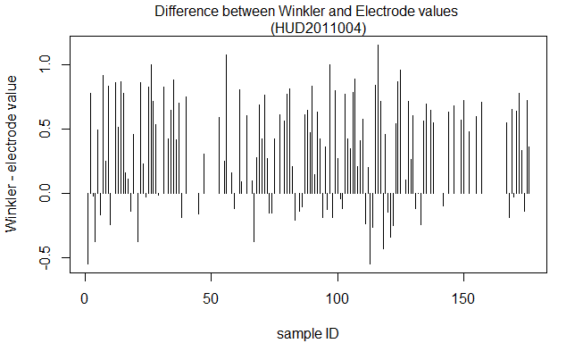

```r
#plot differences (wink-elec)
plot(unlist(match), unlist(H11004_wink_elec), type = 'h', xlab = 'sample ID', ylab = 'Winkler - electrode value')
mtext('Difference between Winkler and Electrode values
      (HUD2011004)')
```

This process was then repeated for each cruise.

HUD2011043

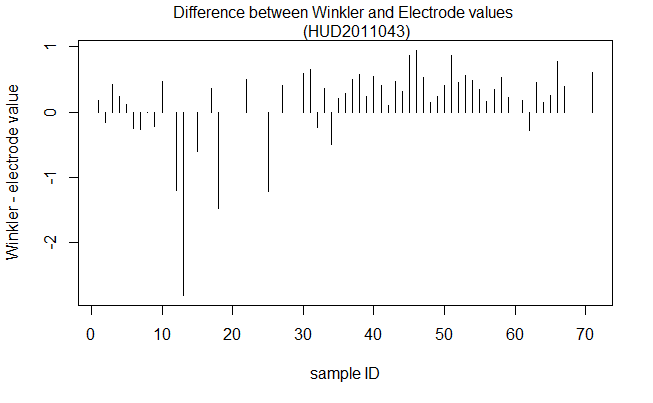

```r
#hud2011043
#pull sample ids
H11043_wink_id <- H11043_bcd$DIS_DETAIL_COLLECTOR_SAMP_ID[H11043_wink] #length = 310
H11043_elec_id <- H11043_bcd$DIS_DETAIL_COLLECTOR_SAMP_ID[H11043_elec] #length = 71
#These are different lengths meaning not all sample ids can match
length(H11043_elec_id) <- 310 #fix length issue
#combine lists
H11043_id <- cbind(H11043_wink_id, H11043_elec_id)
#compare lists
H11043_id_match <- H11043_wink_id == H11043_elec_id #useless
#most sample id's match but they are ordered differently, must compare 1 by 1
#create matching list wink:elec
match2 <- list()
for (i in 1:310){
  h <- H11043_wink_id[i] == H11043_elec_id
  m <- grep(h, pattern = TRUE)
  #m <- grep(pattern = H11004_wink_id[i], H11004_elec_id)
  if(length(m >0)){
    match2[i] <- m
  }else{
    match2[i] <- NULL
  }
}
#name list wink:elec
#why is list one short of full length?
names(match2) <- c(1:309)
H11043_wink_elec <- list()
for (i in 1:309){
  if(!is.null(match2[[i]])){
    H11043_wink_elec[i] <- H11043_wink_data[[i]] - H11043_elec_data[[match2[[i]]]]
  }else{
    H11043_wink_elec[i] <- NULL
  }
}
#keeps subtracting one from length?
length(H11043_wink_elec) <- 310
#plot differences (wink-elec)
plot(unlist(match2), unlist(H11043_wink_elec), type = 'h', xlab = 'sample ID', ylab = 'Winkler - electrode value')
mtext('Difference between Winkler and Electrode values
      (HUD2011043)')
```

HUD2012042

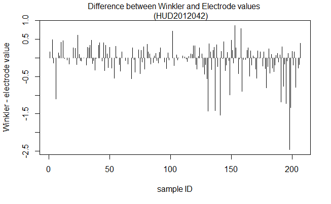

```r
#Hud2012042
#pull sample ids
H12042_wink_id <- H12042_bcd$DIS_DETAIL_COLLECTOR_SAMP_ID[H12042_wink] #length = 486
H12042_elec_id <- H12042_bcd$DIS_DETAIL_COLLECTOR_SAMP_ID[H12042_elec] #length = 207
#These are different lengths meaning not all sample ids can match
length(H12042_elec_id) <- 486 #fix length issue
#combine lists
H12042_id <- cbind(H12042_wink_id, H12042_elec_id)
#compare lists
H12042_id_match <- H12042_wink_id == H12042_elec_id #useless
#most sample id's match but they are ordered differently, must compare 1 by 1
#create matching list wink:elec
match3 <- list()
for (i in 1:486){
  h <- H12042_wink_id[i] == H12042_elec_id
  m <- grep(h, pattern = TRUE)
  #m <- grep(pattern = H11004_wink_id[i], H11004_elec_id)
  if(length(m >0)){
    match3[i] <- m
  }else{
    match3[i] <- NULL
  }
}
#name list wink:elec
#why is list only 175 items, should be 176, last is NULL?
names(match3) <- c(1:486)
H12042_wink_elec <- list()
for (i in 1:486){
  if(!is.null(match3[[i]])){
    H12042_wink_elec[i] <- H12042_wink_data[[i]] - H12042_elec_data[[match3[[i]]]]
  }else{
    H12042_wink_elec[i] <- NULL
  }
}
#keeps subtracting one from length?
length(H12042_wink_elec) <- 486
#plot differences (wink-elec)
plot(unlist(match3), unlist(H12042_wink_elec), type = 'h', xlab = 'sample ID', ylab = 'Winkler - electrode value')
mtext('Difference between Winkler and Electrode values
      (HUD2012042)')
```

Further statistics were calculated including a t test and confidence intervals

```r
##is the mean difference significantly diffrent from zero?
  #t test
a <- 0.01
H12042_t <- t.test(x = unlist(H12042_wink_elec))
H11043_t <- t.test(x = unlist(H11043_wink_elec))
H11004_t <- t.test(x = unlist(H11004_wink_elec))
ci1 <- H11004_t$conf.int
ci2 <- H11043_t$conf.int
ci3 <- H12042_t$conf.int
x <- c(1: 200)
a <- unlist(H11004_wink_elec)
b <- unlist(H11043_wink_elec)
c <- unlist(H12042_wink_elec)
length(a) <- 200
length(b) <- 200
length(c) <- 200
plot(x, a, col = 'black', ylim = c(-2.5, 2.5), xlab = 'Sample ID', ylab = "Difference Winkler - Electrode (ml/l)" )
mtext('Difference between
      Winkler and Electrode Methods')
```

```r
mtext("Black: HUD2011004,
  Blue: HUD2011043,
  Red: HUD2012042", side = 1, cex = 0.8, line = -2)
par(new = TRUE)
```

```r
plot(x, b, col = 'blue', ylim = c(-2.5, 2.5), axes = FALSE, xlab = '', ylab = '')
par(new = TRUE)
```

```r
plot(x, c, col = 'red', ylim = c(-2.5, 2.5), axes = FALSE, xlab = '', ylab = '')
#confidence interval lines
abline(h = ci1[[1]], col = 'black')
```

```r
abline(h = ci1[[2]], col = 'black')
abline(h = ci2[[1]], col = 'blue')
```

```r
abline(h = ci2[[2]], col = 'blue')
abline(h = ci3[[1]], col = 'red')
```

[figure not shown]

```r
abline(h = ci3[[2]], col = 'red')
```

```r
#eliminate outliers (past 1.5 IQT, and flagged values)
#calculate iqt
H11004_iqr<- IQR(H11004_wink_data, na.rm = TRUE)
H11043_iqr <- IQR(H11043_wink_data, na.rm = TRUE)
H12042_iqr <- IQR(H12042_wink_data, na.rm = TRUE)
#calculate 1.5 iqt
H11004_iqr_1.5 <- 1.5*(H11004_iqr)
H11043_iqr_1.5 <- 1.5*(H11043_iqr)
H12042_iqr_1.5 <- 1.5*(H12042_iqr)
#calculate mean
H11004_wink_mean <- mean(H11004_wink_data)
H11043_wink_mean <- mean(H11043_wink_data)
H12042_wink_mean <- mean(H12042_wink_data)
```

This was then plotted so data could be visualized and ensure correct removal of outliers

```r
#hud2011004
plot( c(1:length(H11004_wink_data)), unlist(H11004_wink_data), xlab = 'Sample ID', ylab = 'Oxygen COncentration (ml/L)')
mtext('Dissolved Oxygen Winkler Measurements
      HUD2011004')
```

```r
par(new = TRUE)
abline(h = H11004_wink_mean, col = 'blue')
```

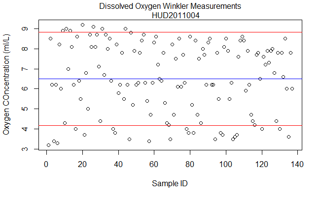

```r
uiqr <- 0.5*(H11004_iqr_1.5) + H11004_wink_mean
liqr <- H11004_wink_mean - 0.5*(H11004_iqr_1.5)
abline(h = uiqr, col = 'red')
abline(h = liqr, col = 'red')
```

```r
#null values outside 1.5 iqt
H11004_wink_data[H11004_wink_data > uiqr] <- NA
H11004_wink_data[H11004_wink_data < liqr] <- NA
plot(c(1:length(H11004_wink_data)), unlist(H11004_wink_data), ylim = c(3,9), xlab = 'Sample ID', ylab = 'Dissolved OXygen (ml/L)')
mtext('Winkler Oxygen Measurements after QC
      HUD2011004')
```

```r
mtext('Red lines represent 1.5 IQT', side = 1, cex = 0.8)
abline(h = uiqr, col = 'red')
```

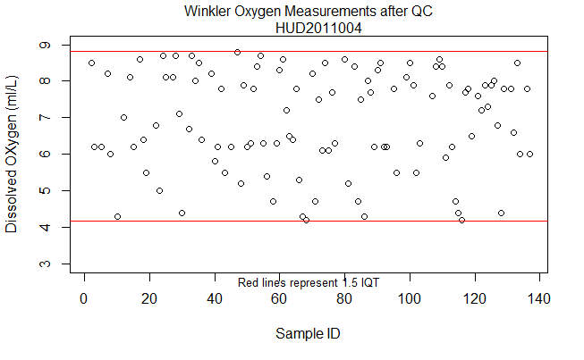

```r
abline(h = liqr, col = 'red')
```

```r
#hud2011043
plot( c(1:length(H11043_wink_data)), unlist(H11043_wink_data), xlab = 'Sample ID', ylab = 'Oxygen COncentration (ml/L)')
mtext('Dissolved Oxygen Winkler Measurements
      HUD2011043')
```

```r
par(new = TRUE)
abline(h = H11043_wink_mean, col = 'blue')
```

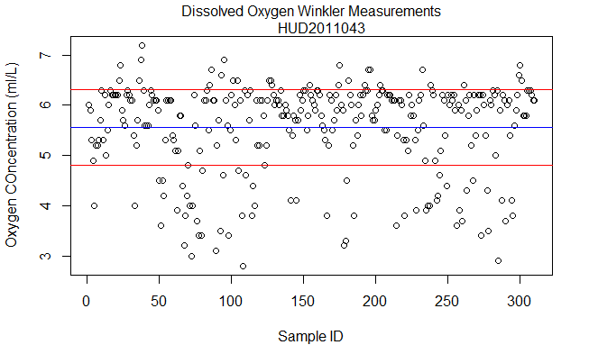

```r
uiqr2 <- 0.5*(H11043_iqr_1.5) + H11043_wink_mean
liqr2 <- H11043_wink_mean - 0.5*(H11043_iqr_1.5)
abline(h = uiqr2, col = 'red')
abline(h = liqr2, col = 'red')
```

```r
#null values outside 1.5 iqt
H11043_wink_data[H11043_wink_data > uiqr2] <- NA
H11043_wink_data[H11043_wink_data < liqr2] <- NA
plot(c(1:length(H11043_wink_data)), unlist(H11043_wink_data), ylim = c(3, 7), xlab = 'Sample ID', ylab = 'Dissolved OXygen (ml/L)')
mtext('Winkler Oxygen Measurements after QC
      HUD2011043')
```

```r
mtext('Red lines represent 1.5 IQT', side = 1, cex = 0.8)
abline(h = uiqr2, col = 'red')
```

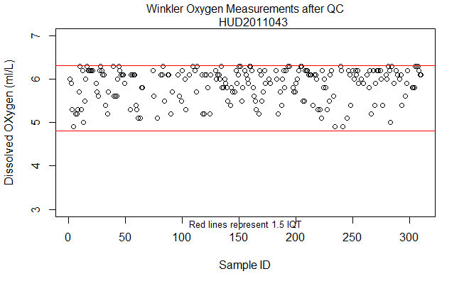

```r
abline(h = liqr2, col = 'red')
```

```r
#hud2012042
plot( c(1:length(H12042_wink_data)), unlist(H12042_wink_data), xlab = 'Sample ID', ylab = 'Oxygen Concentration (ml/L)')
mtext('Dissolved Oxygen Winkler Measurements
      HUD2012042')
```

```r
par(new = TRUE)
abline(h = H12042_wink_mean, col = 'blue')
```

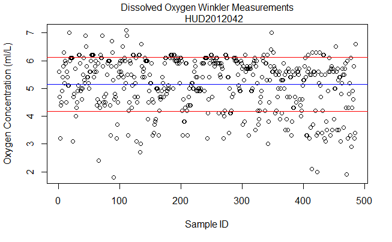

```r
uiqr3 <- 0.5*(H12042_iqr_1.5) + H12042_wink_mean
liqr3 <- H12042_wink_mean - 0.5*(H12042_iqr_1.5)
abline(h = uiqr3, col = 'red')
abline(h = liqr3, col = 'red')
```

```r
#null values outside 1.5 iqt
H12042_wink_data[H12042_wink_data > uiqr3] <- NA
H12042_wink_data[H12042_wink_data < liqr3] <- NA
plot(c(1:length(H12042_wink_data)), unlist(H12042_wink_data), ylim = c(2,7), xlab = 'Sample ID', ylab = 'Dissolved Oxygen (ml/L)')
mtext('Winkler Oxygen Measurements after QC
      HUD2012042')
```

```r
mtext('Red lines represent 1.5 IQT', side = 1, cex = 0.8)
abline(h = uiqr3, col = 'red')
```

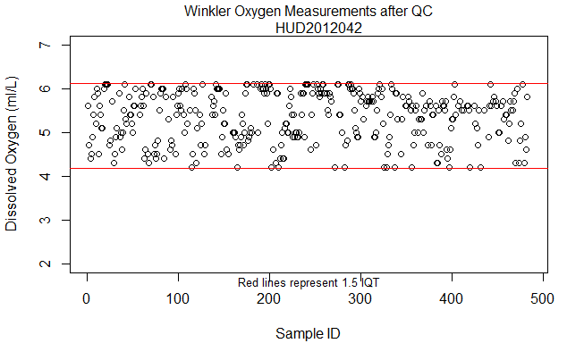

```r
abline(h = liqr3, col = 'red')
```

Differences within individual sample ID’s were then recalculated, removing any samples where the Winkler value was null due to being an outlier.

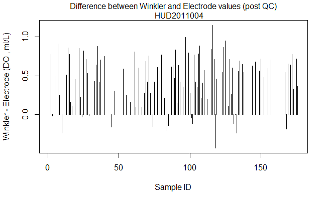

```r
#plot differences after removal
#hud2011004
H11004_wink_elec_1 <- list()
for( i in 1:175){
  if(!is.null(match[[i]])){
    H11004_wink_elec_1[i] <- H11004_wink_data[[i]] - H11004_elec_data[[match[[i]]]]
  }else{
    H11004_wink_elec_1[i] <- NULL
  }
}
plot(unlist(match), unlist(H11004_wink_elec_1), type = 'h', xlab = 'Sample ID', ylab = 'Winkler - Electrode (DO , ml/L)')
mtext('Difference between Winkler and Electrode values (post QC)
      HUD2011004')
```

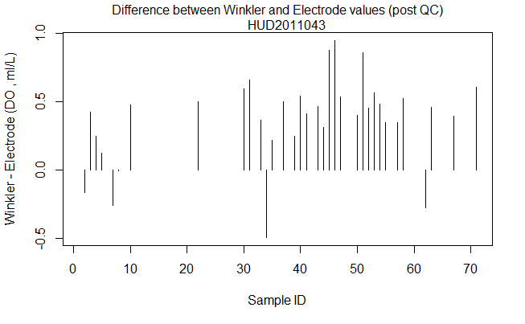

```r
#hud2011043
H11043_wink_elec_1 <- list()
for( i in 1:309){
  if(!is.null(match2[[i]])){
    H11043_wink_elec_1[i] <- H11043_wink_data[[i]] - H11043_elec_data[[match2[[i]]]]
  }else{
    H11043_wink_elec_1[i] <- NULL
  }
}
plot(unlist(match2), unlist(H11043_wink_elec_1), type = 'h', xlab = 'Sample ID', ylab = 'Winkler - Electrode (DO , ml/L)')
mtext('Difference between Winkler and Electrode values (post QC)
      HUD2011043')
```

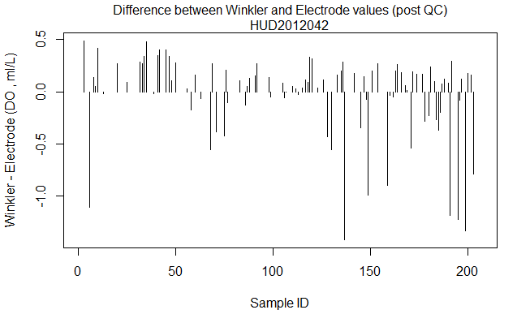

```r
#hud2012042
H12042_wink_elec_1 <- list()
for( i in 1:486){
  if(!is.null(match3[[i]])){
    H12042_wink_elec_1[i] <- H12042_wink_data[[i]] - H12042_elec_data[[match3[[i]]]]
  }else{
    H12042_wink_elec_1[i] <- NULL
  }
}
plot(unlist(match3), unlist(H12042_wink_elec_1), type = 'h', xlab = 'Sample ID', ylab = 'Winkler - Electrode (DO , ml/L)')
mtext('Difference between Winkler and Electrode values (post QC)
      HUD2012042')
```

Depth profiles were then visualized again to see if there were any significant visual patterns or relationship between depth and offset between Winkler and probe data.

```r
##post QC depth profiles
plot(H11004_wink_data, H11004_wink_dpth, ylim = (c(5000, 0)), xlim = c(4,9), xlab = 'DO ml/L', ylab = 'Depth (m)', main = 'HUD2011004')
par(new = TRUE)
```

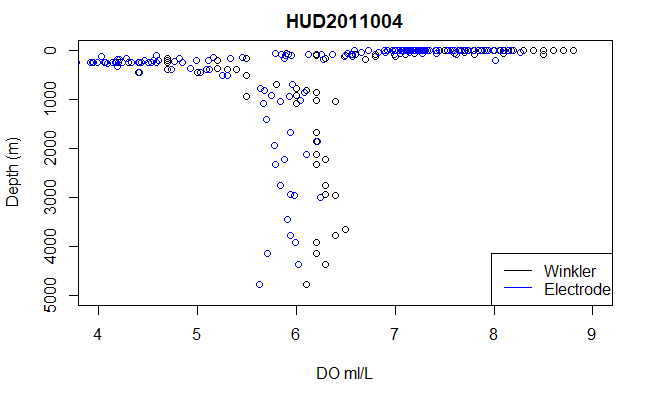

```r
plot(H11004_elec_data, H11004_elec_dpth, ylim = (c(5000, 0)),xlim = c(4,9), axes = FALSE, col = 'blue', xlab = '', ylab = '')
legend('bottomright',  c('Winkler', 'Electrode'), col = c('black', 'blue'), lty = 1)
```

```r
plot(H11043_wink_data, H11043_wink_dpth, ylim = (c(5000, 0)), xlim = c(4,9), xlab = 'DO ml/L', ylab = 'Depth (m)', main = 'HUD2011043')
par(new = TRUE)
```

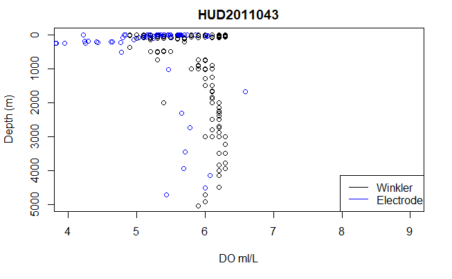

```r
plot(H11043_elec_data, H11043_elec_dpth, ylim = (c(5000, 0)),xlim = c(4,9), axes = FALSE, col = 'blue', xlab = '', ylab = '')
legend('bottomright',  c('Winkler', 'Electrode'), col = c('black', 'blue'), lty = 1)
```

```r
plot(H12042_wink_data, H12042_wink_dpth, ylim = (c(5000, 0)), xlim = c(4,9), xlab = 'DO ml/L', ylab = 'Depth (m)', main = 'HUD2012042')
par(new = TRUE)
```

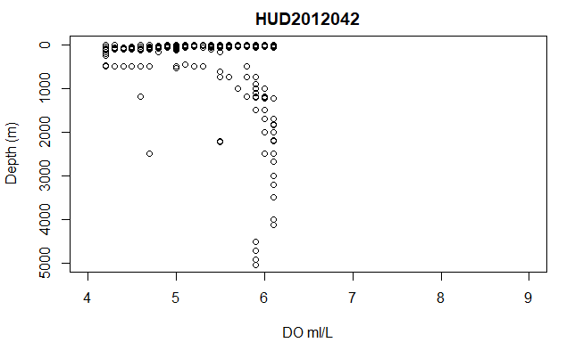

```r
plot(H12042_elec_data, H12042_elec_dpth, ylim = (c(5000, 0)),xlim = c(4,9), axes = FALSE, col = 'blue', xlab = '', ylab = '')
legend('bottomright',  c('Winkler', 'Electrode'), col = c('black', 'blue'), lty = 1, cex = 0.8)
```

The next step in Analysis was to plot Winkler and Electrode data against each other for each cruise to attempt a linear regression. In an ideal situtation the data would have presented with a 1:1 relationship, high correlation and minimal offset (intercept).

For cruise HUD2011004

```r
H11004_winkelec <- matrix(NA, nrow = 175, ncol = 2)
for( i in 1:175){
  if(!is.null(match[[i]])){
    H11004_winkelec[i,1] <- H11004_wink_data[[i]]
    H11004_winkelec[i,2] <- H11004_elec_data[[match[[i]]]]
  # }else{
  #   H11004_winkelec[i,] <- NULL
   }
}
plot(H11004_winkelec[,1], H11004_winkelec[,2], xlim = c(0,7), ylim = c(0,7),xlab = 'Winkler Data', ylab = 'Electrode Data')
par(new = TRUE)
```

```r
lm <- lm(H11004_winkelec[,1] ~ H11004_winkelec[,2])
abline(lm)
abline(coef = c(0, 1), col = 'red')
```

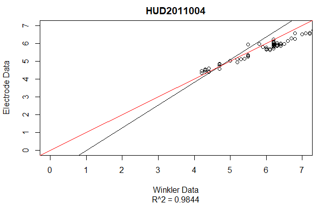

```r
title(main = 'HUD2011004')
title(sub = 'R^2 = 0.9844')
```

Where black line represents simple linear regression on the data and red line represents perfect 1:1 relationship with 0 intercept.

Statistic summary

```r
summary(lm)
```

```
Call:
lm(formula = H11004_winkelec[, 1] ~ H11004_winkelec[, 2])

Residuals:
     Min       1Q   Median       3Q      Max
-0.75153 -0.08761  0.01495  0.10951  0.43717

Coefficients:
                     Estimate Std. Error t value Pr(>|t|)
(Intercept)          -1.30733    0.10351  -12.63   <2e-16 ***
H11004_winkelec[, 2]  1.27511    0.01592   80.10   <2e-16 ***
---
Signif. codes:  0 ‘***’ 0.001 ‘**’ 0.01 ‘*’ 0.05 ‘.’ 0.1 ‘ ’ 1

Residual standard error: 0.1696 on 102 degrees of freedom
  (71 observations deleted due to missingness)
Multiple R-squared:  0.9844,    Adjusted R-squared:  0.9842
F-statistic:  6417 on 1 and 102 DF,  p-value: < 2.2e-16
```

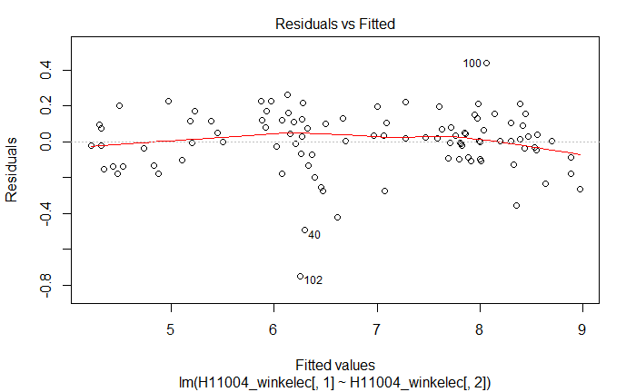

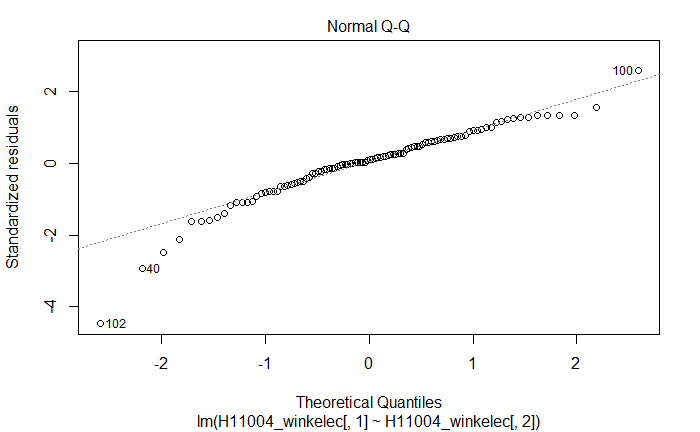

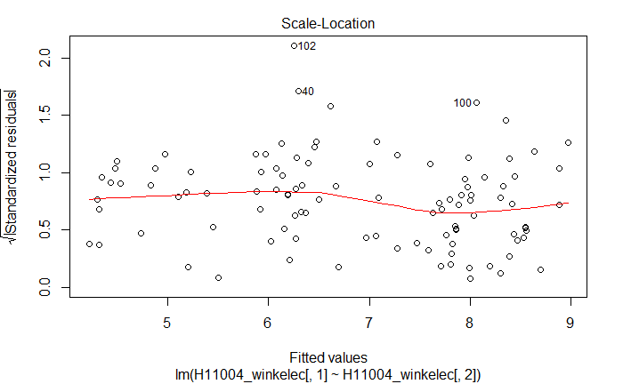

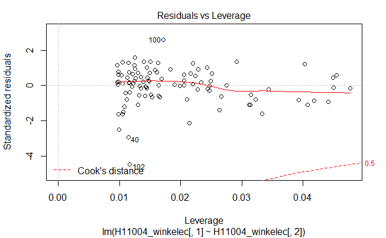

```r
plot(lm)
```

For cruise HUD2011043

```r
H11043_winkelec <- matrix(NA, nrow = 310, ncol = 2)
for( i in 1:309){
  if(!is.null(match2[[i]])){
    H11043_winkelec[i,1] <- H11043_wink_data[[i]]
    H11043_winkelec[i,2] <- H11043_elec_data[[match2[[i]]]]
  # }else{
  #   H11043_winkelec[i,] <- NULL
   }
}
plot(H11043_winkelec[,1], H11043_winkelec[,2], xlim = c(0, 7), ylim = c(0,7), xlab = 'Winkler Data', ylab = 'Electrode Data')
par(new = TRUE)
```

```r
lm2 <- lm(H11043_winkelec[,1] ~ H11043_winkelec[,2])
abline(lm2)
abline(coef = c(0, 1), col = 'red')
```

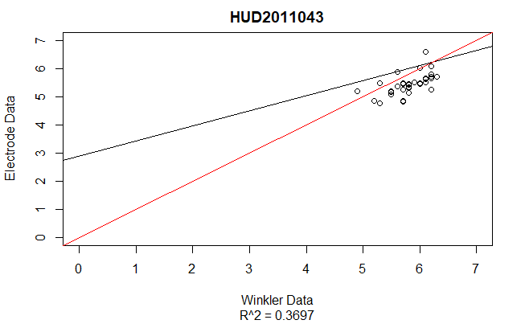

```r
title(main = 'HUD2011043')
title(sub = 'R^2 = 0.3697')
```

Where black line represents simple linear regression on the data and red line represents perfect 1:1 relationship with 0 intercept.